# US civilian deaths from police officers in one year

**Hui Wang**

## Overview

There are thousands of US civilians killed by police officers for almost every year. It is important to be aware of the numbers of deaths and the data behind them. From that, this tutorial introduces a deep analysis on US civilian deaths from police officers in 2016. The tutorial includes three main parts. The first part will include data collecting and data cleaning processes. The second part will demonstrate how to analyze the given data and display visualization. The third part will come up with a linear regression model to process the analysis and verify the hypotheses implied from it.

## Tools

- pandas
- numpy
- scikit-learn
- matplotlib
- folium

For the dataset, the homicide reports data can be retrived at https://www.kaggle.com/the-guardian/the-counted#2016.csv

## Part 1: Data Preparation

The first thing I need to do is download the dataset at https://www.kaggle.com/the-guardian/the-counted#2016.csv. The file downloaded will be in form of a CSV called 2016.csv. Then, I need to apply pandas libraries to help me initialize the data in nice frames and columns.

```python
!pip install folium
import pandas as pd
import folium
import matplotlib.pyplot as plt
import statsmodels.api as sm
from sklearn import linear_model
import os
from branca.utilities import split_six
from statsmodels.formula.api import ols
```

```
You are using pip version 9.0.3, however version 18.1 is available.
```

```python
#Load the csv file and make dataframe
data = pd.read_csv("2016.csv", encoding='latin-1')
#Display the first 5 rows of the table
data.head()
```

|  | uid | name | age | gender | raceethnicity | armed | month | day | year | streetaddress | city | state | latitude | longitude | classification | lawenforcementagency |
| --- | --- | --- | --- | --- | --- | --- | --- | --- | --- | --- | --- | --- | --- | --- | --- | --- |
| 0 | 20161 | Joshua Sisson | 30 | Male | White | Knife | January | 1 | 2016 | 4200 6th Ave | San Diego | CA | 32.754508 | -117.159648 | Gunshot | San Diego Police Department |
| 1 | 20162 | Germonta Wallace | 30 | Male | Black | Firearm | January | 3 | 2016 | 2600 Watson Dr | Charlotte | NC | 35.218426 | -80.885428 | Gunshot | Charlotte-Mecklenburg Police Department |
| 2 | 20163 | Sean O'Brien | 37 | Male | White | Knife | January | 2 | 2016 | 100 Washington St | Livingston | MT | 45.655904 | -110.573298 | Gunshot | Livingston Police Department |
| 3 | 20164 | Rodney Turner | 22 | Male | Black | Firearm | January | 4 | 2016 | 3600 NW 42nd St | Oklahoma City | OK | 35.514287 | -97.581618 | Gunshot | Oklahoma City Police Department |
| 4 | 20165 | Eric Senegal | 27 | Male | Black | Unknown | January | 4 | 2016 | Gene Stanley Rd | Ragley | LA | 30.493824 | -93.207608 | Gunshot | Beauregard Parish Sheriff's Office |

### 1.1 Data Overview

The data contains some information for me to analyze such as the age, gender, race, and locations.

### 1.2 Data Tidying

When I look at the data table, there are several columns that seem to be unnecessary to the analysis. For example, I do not need the data for names for this project since I'm more curisous about the age, gender, race, and locations. In addition, the month, day, and year can be dropped because the data are only for 2016.

```python
#drop all unnecessary columns
data = data.drop('uid', 1)
data = data.drop('name', 1)
data = data.drop('month', 1)
data = data.drop('day', 1)
data = data.drop('year', 1)
data = data.drop('streetaddress', 1)
data = data.drop('city', 1)
data = data.drop('lawenforcementagency', 1)
data = data.drop('classification', 1)
data
```

|  | age | gender | raceethnicity | armed | state | latitude | longitude |
| --- | --- | --- | --- | --- | --- | --- | --- |
| 0 | 30 | Male | White | Knife | CA | 32.754508 | -117.159648 |
| 1 | 30 | Male | Black | Firearm | NC | 35.218426 | -80.885428 |
| 2 | 37 | Male | White | Knife | MT | 45.655904 | -110.573298 |
| 3 | 22 | Male | Black | Firearm | OK | 35.514287 | -97.581618 |
| 4 | 27 | Male | Black | Unknown | LA | 30.493824 | -93.207608 |
| 5 | 54 | Male | White | Knife | PA | 39.922928 | -75.308044 |
| 6 | 29 | Male | White | No | WA | 46.952729 | -122.891732 |
| 7 | 52 | Male | White | Firearm | CA | 40.613656 | -122.369757 |
| 8 | 38 | Male | White | Non-lethal firearm | IL | 42.458637 | -87.836098 |
| 9 | 28 | Male | Hispanic/Latino | Other | CA | 37.584059 | -120.947469 |
| 10 | 39 | Male | White | Knife | TN | 36.302638 | -82.379082 |
| 11 | 32 | Male | Hispanic/Latino | Firearm | NM | 33.646863 | -105.872185 |
| 12 | 34 | Male | White | Firearm | KY | NaN | NaN |
| 13 | 37 | Male | White | Other | WA | 46.160115 | -122.668867 |
| 14 | 45 | Female | White | Non-lethal firearm | MD | 39.717655 | -75.958603 |
| 15 | 50 | Male | White | Firearm | GA | 34.132797 | -84.676530 |
| 16 | 26 | Male | White | Knife | WI | 42.609229 | -88.488070 |
| 17 | 45 | Male | White | Non-lethal firearm | OH | 39.118345 | -84.585281 |
| 18 | 32 | Male | White | Firearm | CO | 39.754862 | -105.015916 |
| 19 | 56 | Male | White | No | CA | 34.290397 | -118.449468 |
| 20 | 12 | Female | White | No | PA | 40.398426 | -77.033549 |
| 21 | 49 | Male | Native American | Knife | AK | 61.191612 | -149.897963 |
| 22 | 58 | Male | White | Firearm | VA | 36.856488 | -76.188148 |
| 23 | 41 | Male | White | Firearm | IL | 37.831605 | -89.143118 |
| 24 | 60 | Male | White | Firearm | WA | 47.196611 | -120.954178 |
| 25 | 39 | Male | Hispanic/Latino | Knife | CA | 34.419564 | -118.459935 |
| 26 | 25 | Female | White | No | CA | 32.792890 | -116.978261 |
| 27 | 24 | Male | Hispanic/Latino | Knife | CA | 34.230135 | -118.459892 |
| 28 | 34 | Male | Hispanic/Latino | Non-lethal firearm | CA | 34.103763 | -118.358812 |
| 29 | 19 | Male | Black | Firearm | FL | 26.682873 | -80.676923 |
| ... | ... | ... | ... | ... | ... | ... | ... |
| 1050 | 31 | Male | White | Unknown | OR | 44.057433 | -121.313999 |
| 1051 | Unknown | Male | Unknown | Firearm | AL | 34.021724 | -86.018656 |
| 1052 | 53 | Female | White | Knife | FL | 28.006171 | -81.567837 |
| 1053 | 48 | Male | Asian/Pacific Islander | Other | CA | 34.018342 | -118.063507 |
| 1054 | 61 | Male | White | Firearm | FL | 30.047892 | -81.924651 |
| 1055 | 29 | Male | Black | Knife | DC | 38.930812 | -76.962802 |
| 1056 | 33 | Male | Unknown | Firearm | AR | 35.672292 | -91.726798 |
| 1057 | 30 | Male | White | Firearm | OR | 45.405790 | -122.796307 |
| 1058 | 35 | Male | White | Firearm | CA | 39.182621 | -121.018005 |
| 1059 | Unknown | Female | White | Firearm | TX | 29.553319 | -95.367586 |
| 1060 | 26 | Male | White | Non-lethal firearm | WV | NaN | NaN |
| 1061 | 41 | Male | Hispanic/Latino | Knife | IL | 41.848740 | -87.806194 |
| 1062 | 36 | Male | White | Firearm | TX | 28.707347 | -98.352927 |
| 1063 | 34 | Male | White | Other | KY | 38.427133 | -85.343282 |
| 1064 | 28 | Male | White | Unknown | TN | 35.709287 | -86.916101 |
| 1065 | 52 | Male | Unknown | Firearm | MD | 39.211787 | -76.028571 |
| 1066 | 20 | Male | White | Knife | PA | 40.314177 | -80.491948 |
| 1067 | Unknown | Male | Unknown | Firearm | SD | NaN | NaN |
| 1068 | 33 | Male | Hispanic/Latino | Firearm | CA | 34.021519 | -118.162618 |
| 1069 | 38 | Male | White | No | TX | 32.760258 | -97.787905 |
| 1070 | 39 | Male | Black | No | NC | 35.410511 | -80.124056 |
| 1071 | 44 | Male | White | Vehicle | TN | 35.476582 | -84.416241 |
| 1072 | 86 | Male | White | No | IN | 39.853447 | -85.991504 |
| 1073 | 87 | Female | White | No | IN | 39.853447 | -85.991504 |
| 1074 | 39 | Male | White | No | OK | 36.397563 | -97.896508 |
| 1075 | 28 | Male | White | No | IN | 41.580249 | -87.175986 |
| 1076 | Unknown | Male | Unknown | Knife | AZ | 33.553139 | -112.053701 |
| 1077 | 21 | Male | Black | Disputed | FL | 25.604854 | -80.356059 |
| 1078 | Unknown | Male | Unknown | Knife | FL | 26.708766 | -80.248635 |
| 1079 | 32 | Male | White | Unknown | PA | NaN | NaN |

1080 rows × 7 columns

When I look at the table, I notice that there are some cases that were missing. Therefore, I also dropped the rows that contains missing and incorrect data.

```python
data = data[data['raceethnicity'] != 'Unknown']
data = data[data['armed'] != 'Unknown']
data = data[data['age'] != 'Unknown']
data = data[data['age'] != '40s']
data = data[pd.notnull(data['latitude'])]
data.loc[data.armed != 'No', 'armed'] = 'Yes'
data.head()
```

|  | age | gender | raceethnicity | armed | state | latitude | longitude |
| --- | --- | --- | --- | --- | --- | --- | --- |
| 0 | 30 | Male | White | Yes | CA | 32.754508 | -117.159648 |
| 1 | 30 | Male | Black | Yes | NC | 35.218426 | -80.885428 |
| 2 | 37 | Male | White | Yes | MT | 45.655904 | -110.573298 |
| 3 | 22 | Male | Black | Yes | OK | 35.514287 | -97.581618 |
| 5 | 54 | Male | White | Yes | PA | 39.922928 | -75.308044 |

## Part 2: Data Analysis and Visualization

Now, the data is ready to be analyzed. In this part, I would like to visualize the data with some plots and map in order to see the relations for each category with the number of deaths.

### 2.1 Number of Deaths By Age

First thing I would like to analyze is the number of deaths happened at different ages.

### 2.1.1 Extract the Number of Deaths with Age

I apply pandas function "groupby()" and "count()" to create a new dataframe that count the number of deaths for each provided age.

```python
#Use groupby and count functions to count the number of deaths at any age
data_by_age = data.copy().groupby(data['age'], as_index=True, group_keys=True).count()
#Put another column that later will be replaced by counts.
count_by_age = data_by_age[['gender']].reset_index()
#Replace gender with number
count_by_age = count_by_age.rename(index=str, columns={'gender' : 'number'})

#Convert all ages from str to int for later calculation
for i in range(0,len(count_by_age)):
    count_by_age['age'][i] = int(count_by_age['age'][i])
count_by_age
```

|  | age | number |
| --- | --- | --- |
| 0 | 10 | 1 |
| 1 | 12 | 1 |
| 2 | 13 | 1 |
| 3 | 14 | 1 |
| 4 | 15 | 3 |
| 5 | 16 | 6 |
| 6 | 17 | 3 |
| 7 | 18 | 17 |
| 8 | 19 | 19 |
| 9 | 20 | 12 |
| 10 | 21 | 20 |
| 11 | 22 | 27 |
| 12 | 23 | 23 |
| 13 | 24 | 26 |
| 14 | 25 | 40 |
| 15 | 26 | 27 |
| 16 | 27 | 21 |
| 17 | 28 | 22 |
| 18 | 29 | 30 |
| 19 | 30 | 33 |
| 20 | 31 | 35 |
| 21 | 32 | 27 |
| 22 | 33 | 32 |
| 23 | 34 | 21 |
| 24 | 35 | 26 |
| 25 | 36 | 31 |
| 26 | 37 | 30 |
| 27 | 38 | 39 |
| 28 | 39 | 19 |
| 29 | 40 | 16 |
| ... | ... | ... |
| 40 | 51 | 10 |
| 41 | 52 | 14 |
| 42 | 53 | 16 |
| 43 | 54 | 9 |
| 44 | 55 | 13 |
| 45 | 56 | 11 |
| 46 | 57 | 4 |
| 47 | 58 | 8 |
| 48 | 59 | 12 |
| 49 | 60 | 4 |
| 50 | 61 | 6 |
| 51 | 62 | 5 |
| 52 | 63 | 6 |
| 53 | 64 | 3 |
| 54 | 65 | 2 |
| 55 | 66 | 2 |
| 56 | 67 | 2 |
| 57 | 68 | 2 |
| 58 | 69 | 4 |
| 59 | 70 | 2 |
| 60 | 71 | 1 |
| 61 | 72 | 1 |
| 62 | 73 | 2 |
| 63 | 76 | 2 |
| 64 | 80 | 1 |
| 65 | 82 | 1 |
| 66 | 83 | 1 |
| 67 | 84 | 1 |
| 68 | 86 | 2 |
| 69 | 87 | 1 |

70 rows × 2 columns

### 2.1.2 Plot Number of Deaths Vs Age

Next, I will plot the data to get the number of deaths Vs age based on the previous dataframe

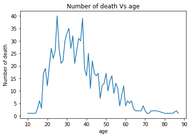

```python
plt.plot(count_by_age['age'], count_by_age['number'])
plt.ylabel('Number of death')
plt.xlabel('age')
plt.title('Number of death Vs age')
plt.show()
```

From this plot, I can see that the most deaths occur at the age from 20 to 40.

```python
print("The average age of deaths is: " + str(sum(count_by_age['age']*count_by_age['number'])/ \
                                                    count_by_age['number'].sum()) + " years old")
```

```
The average age of deaths is: 36.7822757112 years old
```

By caculating the average age, I get confirmed that the data have an average age for deaths at about 37 years old, which is between 20 and 40 years old.

### 2.2 Number of Deaths By State

Now I want to know how many deaths happened in each state.

### 2.2.1 Extract the Number of deaths with State

I will use similar steps as above.

```python
data_by_state = data.copy().groupby(data['state'], as_index=True, group_keys=True).count()
count_by_state = data_by_state[['age']].reset_index()
count_by_state = count_by_state.rename(index=str, columns={'age' : 'number'})
count_by_state
```

|  | state | number |
| --- | --- | --- |
| 0 | AK | 7 |
| 1 | AL | 23 |
| 2 | AR | 18 |
| 3 | AZ | 41 |
| 4 | CA | 128 |
| 5 | CO | 23 |
| 6 | CT | 4 |
| 7 | DC | 5 |
| 8 | DE | 1 |
| 9 | FL | 65 |
| 10 | GA | 24 |
| 11 | HI | 6 |
| 12 | IA | 4 |
| 13 | ID | 5 |
| 14 | IL | 25 |
| 15 | IN | 18 |
| 16 | KS | 9 |
| 17 | KY | 17 |
| 18 | LA | 16 |
| 19 | MA | 13 |
| 20 | MD | 15 |
| 21 | ME | 2 |
| 22 | MI | 15 |
| 23 | MN | 13 |
| 24 | MO | 18 |
| 25 | MS | 8 |
| 26 | MT | 5 |
| 27 | NC | 32 |
| 28 | ND | 1 |
| 29 | NE | 5 |
| 30 | NH | 2 |
| 31 | NJ | 11 |
| 32 | NM | 20 |
| 33 | NV | 11 |
| 34 | NY | 23 |
| 35 | OH | 26 |
| 36 | OK | 26 |
| 37 | OR | 14 |
| 38 | PA | 19 |
| 39 | RI | 2 |
| 40 | SC | 16 |
| 41 | SD | 4 |
| 42 | TN | 21 |
| 43 | TX | 76 |
| 44 | UT | 6 |
| 45 | VA | 18 |
| 46 | VT | 2 |
| 47 | WA | 21 |
| 48 | WI | 18 |
| 49 | WV | 10 |
| 50 | WY | 2 |

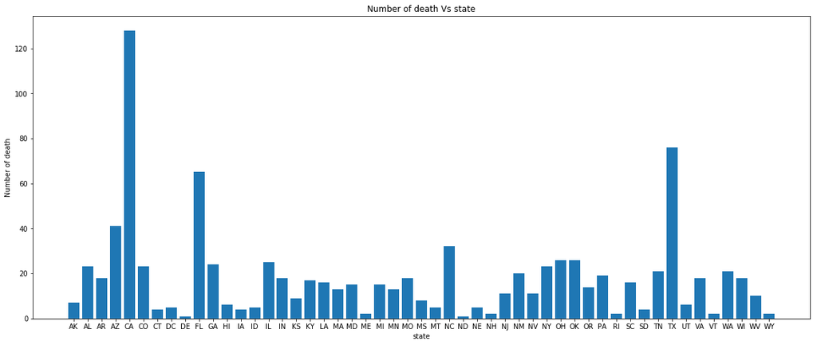

```python
plt.figure(figsize=(20, 8))
plt.bar(count_by_state['state'], count_by_state['number'])
plt.ylabel('Number of death')
plt.xlabel('state')
plt.title('Number of death Vs state')
plt.show()
```

I use bar plot in this case because it makes the graph clearer and more understandable. From the plot I can see that most deaths occur in the states with large porpulation such as California and Texas.

### 2.3 Number of Deaths By Gender

Now I want to know how many deaths happened for all genders.

### 2.3.1 Extract the Number of deaths with Gender

I will use similar steps as above.

```python
data_by_gender = data.copy().groupby(data['gender'], as_index=True, group_keys=True).count()
count_by_gender = data_by_gender[['age']].reset_index()
count_by_gender = count_by_gender.rename(index=str, columns={'age' : 'number'})
count_by_gender
```

|  | gender | number |
| --- | --- | --- |
| 0 | Female | 55 |
| 1 | Male | 859 |

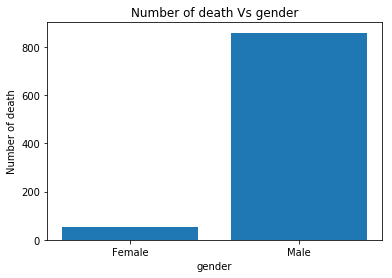

```python
plt.bar(count_by_gender['gender'], count_by_gender['number'])
plt.ylabel('Number of death')
plt.xlabel('gender')
plt.title('Number of death Vs gender')
plt.show()
```

The bar plot shows that there are more male killed than female.

### 2.4 Number of Deaths By Race

Now I want to know how many deaths happened for all races.

### 2.4.1 Extract the Number of deaths with Race

I will use similar steps as above.

```python
data_by_race = data.copy().groupby(data['raceethnicity'], as_index=True, group_keys=True).count()
count_by_race = data_by_race[['age']].reset_index()
count_by_race = count_by_race.rename(index=str, columns={'age' : 'number'})
count_by_race
```

|  | raceethnicity | number |
| --- | --- | --- |
| 0 | Arab-American | 3 |
| 1 | Asian/Pacific Islander | 21 |
| 2 | Black | 238 |
| 3 | Hispanic/Latino | 152 |
| 4 | Native American | 18 |
| 5 | White | 482 |

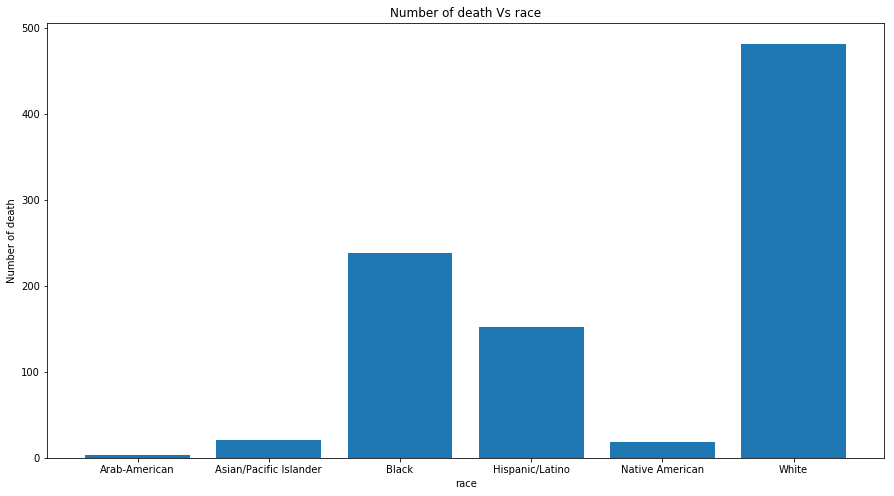

```python
plt.figure(figsize=(15, 8))
plt.bar(count_by_race['raceethnicity'], count_by_race['number'])
plt.ylabel('Number of death')
plt.xlabel('race')
plt.title('Number of death Vs race')
plt.show()
```

The bar plot indicates that there are most white killed, black the second most, and Hispanic/Latino the third most. According to the percentage of races in US https://en.wikipedia.org/wiki/Race_and_ethnicity_in_the_United_States, the plot seems reasonable.

### 2.5 Number of Deaths By Armed

Now I want to know how many deaths happened if the person is armed or not.

### 2.5.1 Extract the Number of deaths with Armed

I will use similar steps as above.

```python
data_by_armed = data.copy().groupby(data['armed'], as_index=True, group_keys=True).count()
count_by_armed = data_by_armed[['age']].reset_index()
count_by_armed = count_by_armed.rename(index=str, columns={'age' : 'number'})
count_by_armed
```

|  | armed | number |
| --- | --- | --- |
| 0 | No | 150 |
| 1 | Yes | 764 |

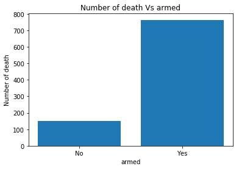

```python
plt.bar(count_by_armed['armed'], count_by_armed['number'])
plt.ylabel('Number of death')
plt.xlabel('armed')
plt.title('Number of death Vs armed')
plt.show()
```

Most people were killed by police officer when they were armed.

### 2.6 Locations of Deaths on Map

I will utilize the folium library to play around with the data and show them on a map.

```python
m = folium.Map(location=[48, -102], zoom_start=3)
loc = folium.FeatureGroup(name='locations')

#Show locations and use Blue as Male and Pink as Female
for i in range(0,len(data)):
    if data['gender'].values[i] == 'Male':
        loc.add_child(folium.Marker(location = [data['latitude'].values[i],data['longitude'].values[i]],
            popup = "Death:" + ". Age: " + str(data['age'].values[i]) + ".Race: " + data['raceethnicity'].values[i] + ". Armed: " + data['armed'].values[i] + ". State: " + data['state'].values[i],
            icon = folium.Icon(color='blue')))
    else:
        loc.add_child(folium.Marker(location = [data['latitude'].values[i],data['longitude'].values[i]],
            popup = "Death:" + ". Age: " + str(data['age'].values[i]) + ".Race: " + data['raceethnicity'].values[i] + ". Armed: " + data['armed'].values[i] + ". State: " + data['state'].values[i],
            icon = folium.Icon(color='pink')))
m.add_child(loc)
m.add_child(folium.map.LayerControl())
m
```

[interactive chart not shown]

## Part 3: Linear Regression and Hypothesis Test

Now I will use linear regression and test my predictions. When doing a linear regression, I'm taking data that is already there and predicting future data base on the patterns of the data I already have. I will take a linear regression of Number of Deaths vs Age data and compare it to another regression when taking account of states using a f test. And I predict that if we can account many factors, I will be able to have more accurate predictions.

### 3.1 Linear Regression on Number of Deaths by Age

I will use the Linear Regression model library to create the model and to get our predicted values.

A short tutorial of linear regression can be found at: https://scikit-learn.org/stable/auto_examples/linear_model/plot_ols.html

```
Text(0.5,1,'deaths vs age with Linear Regression')
```

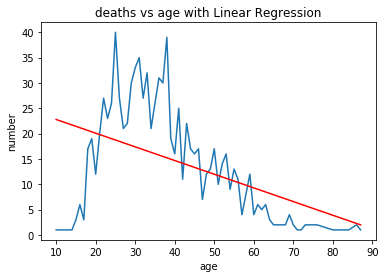

```python
#Linear Regression
reg = linear_model.LinearRegression()
X = [[x] for x in count_by_age['age'].values]
Y = [[y] for y in count_by_age['number'].values]
regfit = reg.fit(X, Y)

#Get predcited Values
pred = []
for x in count_by_age['age'].values:
    pred.append(regfit.predict(x)[0][0])
count_by_age['pred'] = pd.Series(pred, index = count_by_age.index)

#Plot the linear regression line with the data
plt.plot(count_by_age['age'], count_by_age['number'])
plt.plot(count_by_age['age'], count_by_age['pred'], color='red')
plt.xlabel("age")
plt.ylabel("number")
plt.title("deaths vs age with Linear Regression")
```

### 3.2 Fitting the Linear Regression Model

I will group the data by age and State so that I can get the number of deaths associated with those columns. Next I will fit the data to the linear regression model. In order to do this I will use the ols regression library to retrieve the linear regression formula.

I would like to fit two different linear regressions. First is the regression with count associate with age. Second is the regression with both age and state.

```python
#Create new table with copy of data
data_by_state_age = data.copy()
#Get age and state columns
data_by_state_age  = data_by_state_age[['age','state']]
#Get the count associated with age and state
data_by_state_age = data_by_state_age.groupby(['age','state']).size()
data_by_state_age = data_by_state_age.reset_index()
#Rename count column
data_by_state_age['number'] = data_by_state_age[0]
data_by_state_age = data_by_state_age.drop(0,1)
data_by_state_age
```

|  | age | state | number |
| --- | --- | --- | --- |
| 0 | 10 | NY | 1 |
| 1 | 12 | PA | 1 |
| 2 | 13 | OH | 1 |
| 3 | 14 | CA | 1 |
| 4 | 15 | CA | 2 |
| 5 | 15 | MO | 1 |
| 6 | 16 | CA | 2 |
| 7 | 16 | FL | 1 |
| 8 | 16 | IL | 1 |
| 9 | 16 | MO | 1 |
| 10 | 16 | TX | 1 |
| 11 | 17 | AR | 1 |
| 12 | 17 | LA | 1 |
| 13 | 17 | TX | 1 |
| 14 | 18 | AL | 1 |
| 15 | 18 | AR | 1 |
| 16 | 18 | CA | 4 |
| 17 | 18 | GA | 1 |
| 18 | 18 | IL | 1 |
| 19 | 18 | KS | 1 |
| 20 | 18 | MD | 2 |
| 21 | 18 | NC | 2 |
| 22 | 18 | NJ | 1 |
| 23 | 18 | OH | 1 |
| 24 | 18 | VA | 1 |
| 25 | 18 | WI | 1 |
| 26 | 19 | AZ | 2 |
| 27 | 19 | CA | 4 |
| 28 | 19 | FL | 2 |
| 29 | 19 | IL | 1 |
| ... | ... | ... | ... |
| 600 | 64 | CA | 1 |
| 601 | 64 | GA | 1 |
| 602 | 64 | OK | 1 |
| 603 | 65 | TX | 1 |
| 604 | 65 | WV | 1 |
| 605 | 66 | CA | 1 |
| 606 | 66 | NY | 1 |
| 607 | 67 | IN | 1 |
| 608 | 67 | VA | 1 |
| 609 | 68 | MD | 1 |
| 610 | 68 | MI | 1 |
| 611 | 69 | SC | 1 |
| 612 | 69 | VA | 1 |
| 613 | 69 | WI | 1 |
| 614 | 69 | WV | 1 |
| 615 | 70 | OR | 1 |
| 616 | 70 | TN | 1 |
| 617 | 71 | CA | 1 |
| 618 | 72 | OK | 1 |
| 619 | 73 | CA | 1 |
| 620 | 73 | FL | 1 |
| 621 | 76 | NV | 1 |
| 622 | 76 | VT | 1 |
| 623 | 80 | RI | 1 |
| 624 | 82 | WV | 1 |
| 625 | 83 | AR | 1 |
| 626 | 84 | AR | 1 |
| 627 | 86 | CA | 1 |
| 628 | 86 | IN | 1 |
| 629 | 87 | IN | 1 |

630 rows × 3 columns

```python
#Fit the first regression
regression = ols(formula='number ~ age', data=data_by_state_age).fit()
regression.summary()
```

OLS Regression Results

| Dep. Variable: | number | R-squared: | 0.085 |
| --- | --- | --- | --- |
| Model: | OLS | Adj. R-squared: | -0.028 |
| Method: | Least Squares | F-statistic: | 0.7496 |
| Date: | Sat, 15 Dec 2018 | Prob (F-statistic): | 0.932 |
| Time: | 16:25:49 | Log-Likelihood: | -819.86 |
| No. Observations: | 630 | AIC: | 1780. |
| Df Residuals: | 560 | BIC: | 2091. |
| Df Model: | 69 |  |  |
| Covariance Type: | nonrobust |  |  |

|  | coef | std err | t | P>\|t\| | [0.025 | 0.975] |
| --- | --- | --- | --- | --- | --- | --- |
| Intercept | 1.0000 | 0.943 | 1.060 | 0.289 | -0.852 | 2.852 |
| age[T.12] | -1.112e-14 | 1.334 | -8.34e-15 | 1.000 | -2.619 | 2.619 |
| age[T.13] | -5.158e-15 | 1.334 | -3.87e-15 | 1.000 | -2.619 | 2.619 |
| age[T.14] | -6.756e-16 | 1.334 | -5.07e-16 | 1.000 | -2.619 | 2.619 |
| age[T.15] | 0.5000 | 1.155 | 0.433 | 0.665 | -1.769 | 2.769 |
| age[T.16] | 0.2000 | 1.033 | 0.194 | 0.847 | -1.829 | 2.229 |
| age[T.17] | -7.472e-15 | 1.089 | -6.86e-15 | 1.000 | -2.139 | 2.139 |
| age[T.18] | 0.4167 | 0.982 | 0.425 | 0.671 | -1.511 | 2.345 |
| age[T.19] | 0.4615 | 0.979 | 0.472 | 0.637 | -1.461 | 2.384 |
| age[T.20] | 0.3333 | 0.994 | 0.335 | 0.737 | -1.619 | 2.286 |
| age[T.21] | 0.6667 | 0.982 | 0.679 | 0.497 | -1.261 | 2.595 |
| age[T.22] | 0.5882 | 0.970 | 0.606 | 0.545 | -1.318 | 2.494 |
| age[T.23] | 0.2778 | 0.969 | 0.287 | 0.774 | -1.625 | 2.181 |
| age[T.24] | 0.8571 | 0.976 | 0.878 | 0.380 | -1.060 | 2.774 |
| age[T.25] | 0.7391 | 0.963 | 0.767 | 0.443 | -1.153 | 2.631 |
| age[T.26] | 0.9286 | 0.976 | 0.951 | 0.342 | -0.989 | 2.846 |
| age[T.27] | 0.9091 | 0.985 | 0.923 | 0.356 | -1.026 | 2.844 |
| age[T.28] | 0.3750 | 0.972 | 0.386 | 0.700 | -1.534 | 2.284 |
| age[T.29] | 0.5000 | 0.966 | 0.517 | 0.605 | -1.398 | 2.398 |
| age[T.30] | 0.8333 | 0.969 | 0.860 | 0.390 | -1.070 | 2.736 |
| age[T.31] | 0.6667 | 0.965 | 0.691 | 0.490 | -1.229 | 2.563 |
| age[T.32] | 0.5882 | 0.970 | 0.606 | 0.545 | -1.318 | 2.494 |
| age[T.33] | 0.4545 | 0.964 | 0.471 | 0.638 | -1.439 | 2.348 |
| age[T.34] | 0.4000 | 0.974 | 0.411 | 0.681 | -1.513 | 2.313 |
| age[T.35] | 0.5294 | 0.970 | 0.546 | 0.586 | -1.377 | 2.435 |
| age[T.36] | 0.8235 | 0.970 | 0.849 | 0.396 | -1.082 | 2.729 |
| age[T.37] | 0.6667 | 0.969 | 0.688 | 0.492 | -1.236 | 2.570 |
| age[T.38] | 0.6957 | 0.963 | 0.722 | 0.470 | -1.196 | 2.588 |
| age[T.39] | 0.4615 | 0.979 | 0.472 | 0.637 | -1.461 | 2.384 |
| age[T.40] | 0.7778 | 0.994 | 0.782 | 0.434 | -1.175 | 2.730 |
| age[T.41] | 0.5625 | 0.972 | 0.579 | 0.563 | -1.347 | 2.472 |
| age[T.42] | 0.2222 | 0.994 | 0.224 | 0.823 | -1.730 | 2.175 |
| age[T.43] | 0.5714 | 0.976 | 0.585 | 0.559 | -1.346 | 2.489 |
| age[T.44] | -6.042e-15 | 0.970 | -6.23e-15 | 1.000 | -1.906 | 1.906 |
| age[T.45] | 0.7778 | 0.994 | 0.782 | 0.434 | -1.175 | 2.730 |
| age[T.46] | 0.4167 | 0.982 | 0.425 | 0.671 | -1.511 | 2.345 |
| age[T.47] | 0.4000 | 1.033 | 0.387 | 0.699 | -1.629 | 2.429 |
| age[T.48] | 0.3333 | 0.994 | 0.335 | 0.737 | -1.619 | 2.286 |
| age[T.49] | 0.0833 | 0.982 | 0.085 | 0.932 | -1.845 | 2.011 |
| age[T.50] | 0.1333 | 0.974 | 0.137 | 0.891 | -1.780 | 2.046 |
| age[T.51] | 0.1111 | 0.994 | 0.112 | 0.911 | -1.841 | 2.064 |
| age[T.52] | -7.671e-15 | 0.976 | -7.86e-15 | 1.000 | -1.917 | 1.917 |
| age[T.53] | 0.2308 | 0.979 | 0.236 | 0.814 | -1.691 | 2.153 |
| age[T.54] | 0.1250 | 1.000 | 0.125 | 0.901 | -1.840 | 2.090 |
| age[T.55] | 0.1818 | 0.985 | 0.185 | 0.854 | -1.753 | 2.116 |
| age[T.56] | 0.3750 | 1.000 | 0.375 | 0.708 | -1.590 | 2.340 |
| age[T.57] | -7.327e-15 | 1.054 | -6.95e-15 | 1.000 | -2.071 | 2.071 |
| age[T.58] | 0.1429 | 1.008 | 0.142 | 0.887 | -1.837 | 2.123 |
| age[T.59] | 0.5000 | 1.000 | 0.500 | 0.617 | -1.465 | 2.465 |
| age[T.60] | 0.3333 | 1.089 | 0.306 | 0.760 | -1.805 | 2.472 |
| age[T.61] | 0.2000 | 1.033 | 0.194 | 0.847 | -1.829 | 2.229 |
| age[T.62] | 0.2500 | 1.054 | 0.237 | 0.813 | -1.821 | 2.321 |
| age[T.63] | 0.2000 | 1.033 | 0.194 | 0.847 | -1.829 | 2.229 |
| age[T.64] | -7.172e-15 | 1.089 | -6.59e-15 | 1.000 | -2.139 | 2.139 |
| age[T.65] | -4.228e-15 | 1.155 | -3.66e-15 | 1.000 | -2.269 | 2.269 |
| age[T.66] | -7.447e-15 | 1.155 | -6.45e-15 | 1.000 | -2.269 | 2.269 |
| age[T.67] | -3.947e-15 | 1.155 | -3.42e-15 | 1.000 | -2.269 | 2.269 |
| age[T.68] | -5.372e-15 | 1.155 | -4.65e-15 | 1.000 | -2.269 | 2.269 |
| age[T.69] | -8.992e-15 | 1.054 | -8.53e-15 | 1.000 | -2.071 | 2.071 |
| age[T.70] | -7.469e-15 | 1.155 | -6.47e-15 | 1.000 | -2.269 | 2.269 |
| age[T.71] | -8.634e-15 | 1.334 | -6.47e-15 | 1.000 | -2.619 | 2.619 |
| age[T.72] | -1.14e-14 | 1.334 | -8.55e-15 | 1.000 | -2.619 | 2.619 |
| age[T.73] | -3.952e-15 | 1.155 | -3.42e-15 | 1.000 | -2.269 | 2.269 |
| age[T.76] | 4.319e-15 | 1.155 | 3.74e-15 | 1.000 | -2.269 | 2.269 |
| age[T.80] | -1.81e-15 | 1.334 | -1.36e-15 | 1.000 | -2.619 | 2.619 |
| age[T.82] | -5.85e-15 | 1.334 | -4.39e-15 | 1.000 | -2.619 | 2.619 |
| age[T.83] | -1.481e-15 | 1.334 | -1.11e-15 | 1.000 | -2.619 | 2.619 |
| age[T.84] | -1.318e-14 | 1.334 | -9.89e-15 | 1.000 | -2.619 | 2.619 |
| age[T.86] | -5.357e-14 | 1.155 | -4.64e-14 | 1.000 | -2.269 | 2.269 |
| age[T.87] | 9.115e-14 | 1.334 | 6.83e-14 | 1.000 | -2.619 | 2.619 |

| Omnibus: | 428.137 | Durbin-Watson: | 2.024 |
| --- | --- | --- | --- |
| Prob(Omnibus): | 0.000 | Jarque-Bera (JB): | 5546.660 |
| Skew: | 2.900 | Prob(JB): | 0.00 |
| Kurtosis: | 16.329 | Cond. No. | 213. |

Warnings:  
[1] Standard Errors assume that the covariance matrix of the errors is correctly specified.

```python
#Fit the second regression
regression2 = ols(formula='number ~ age + state', data=data_by_state_age).fit()
regression2.summary()
```

OLS Regression Results

| Dep. Variable: | number | R-squared: | 0.404 |
| --- | --- | --- | --- |
| Model: | OLS | Adj. R-squared: | 0.265 |
| Method: | Least Squares | F-statistic: | 2.902 |
| Date: | Sat, 15 Dec 2018 | Prob (F-statistic): | 1.42e-16 |
| Time: | 16:25:49 | Log-Likelihood: | -684.79 |
| No. Observations: | 630 | AIC: | 1610. |
| Df Residuals: | 510 | BIC: | 2143. |
| Df Model: | 119 |  |  |
| Covariance Type: | nonrobust |  |  |

|  | coef | std err | t | P>\|t\| | [0.025 | 0.975] |
| --- | --- | --- | --- | --- | --- | --- |
| Intercept | 0.6602 | 0.877 | 0.753 | 0.452 | -1.062 | 2.383 |
| age[T.12] | 0.0524 | 1.163 | 0.045 | 0.964 | -2.232 | 2.337 |
| age[T.13] | -0.2222 | 1.162 | -0.191 | 0.848 | -2.505 | 2.060 |
| age[T.14] | -1.8033 | 1.150 | -1.568 | 0.117 | -4.063 | 0.456 |
| age[T.15] | -0.5186 | 1.003 | -0.517 | 0.605 | -2.489 | 1.452 |
| age[T.16] | -0.6215 | 0.897 | -0.693 | 0.489 | -2.384 | 1.141 |
| age[T.17] | -0.2880 | 0.947 | -0.304 | 0.761 | -2.149 | 1.573 |
| age[T.18] | 0.2451 | 0.854 | 0.287 | 0.774 | -1.432 | 1.922 |
| age[T.19] | 0.1478 | 0.852 | 0.173 | 0.862 | -1.526 | 1.822 |
| age[T.20] | -0.1340 | 0.865 | -0.155 | 0.877 | -1.832 | 1.565 |
| age[T.21] | 0.4171 | 0.850 | 0.491 | 0.624 | -1.253 | 2.087 |
| age[T.22] | 0.2975 | 0.844 | 0.352 | 0.725 | -1.361 | 1.956 |
| age[T.23] | 0.1416 | 0.843 | 0.168 | 0.867 | -1.515 | 1.798 |
| age[T.24] | 0.5922 | 0.847 | 0.699 | 0.485 | -1.073 | 2.257 |
| age[T.25] | 0.6348 | 0.837 | 0.758 | 0.449 | -1.010 | 2.279 |
| age[T.26] | 0.6003 | 0.849 | 0.707 | 0.480 | -1.067 | 2.268 |
| age[T.27] | 0.5467 | 0.857 | 0.638 | 0.524 | -1.138 | 2.231 |
| age[T.28] | 0.2933 | 0.846 | 0.347 | 0.729 | -1.369 | 1.956 |
| age[T.29] | 0.3746 | 0.842 | 0.445 | 0.657 | -1.280 | 2.029 |
| age[T.30] | 0.6051 | 0.840 | 0.720 | 0.472 | -1.045 | 2.255 |
| age[T.31] | 0.4857 | 0.840 | 0.578 | 0.563 | -1.164 | 2.135 |
| age[T.32] | 0.3444 | 0.841 | 0.409 | 0.682 | -1.308 | 1.997 |
| age[T.33] | 0.2731 | 0.837 | 0.326 | 0.744 | -1.371 | 1.917 |
| age[T.34] | 0.1450 | 0.844 | 0.172 | 0.864 | -1.514 | 1.804 |
| age[T.35] | 0.2472 | 0.844 | 0.293 | 0.770 | -1.411 | 1.906 |
| age[T.36] | 0.7284 | 0.845 | 0.862 | 0.389 | -0.931 | 2.388 |
| age[T.37] | 0.5014 | 0.841 | 0.596 | 0.551 | -1.150 | 2.153 |
| age[T.38] | 0.5868 | 0.836 | 0.702 | 0.483 | -1.055 | 2.229 |
| age[T.39] | 0.0811 | 0.848 | 0.096 | 0.924 | -1.584 | 1.746 |
| age[T.40] | 0.4851 | 0.864 | 0.561 | 0.575 | -1.213 | 2.183 |

[output cut: 90 more lines]

| Omnibus: | 316.545 | Durbin-Watson: | 2.065 |
| --- | --- | --- | --- |
| Prob(Omnibus): | 0.000 | Jarque-Bera (JB): | 3583.577 |
| Skew: | 1.954 | Prob(JB): | 0.00 |
| Kurtosis: | 14.011 | Cond. No. | 222. |

Warnings:  
[1] Standard Errors assume that the covariance matrix of the errors is correctly specified.

### 3.3 Hypothesis Testing

In order to verify the hypothesis, I will apply f-test. The purpose of this test is to verify my linear regression models fit the data well. I will also utilize the statsmodels library to calculate the f-test.

The tutorial of f-test can be found at: https://www.statisticshowto.datasciencecentral.com/probability-and-statistics/hypothesis-testing/f-test/.

The tutorial of anova function from the statsmodels library can be found at: https://www.marsja.se/four-ways-to-conduct-one-way-anovas-using-python/

```python
result = sm.stats.anova_lm(regression)
result
```

|  | df | sum_sq | mean_sq | F | PR(>F) |
| --- | --- | --- | --- | --- | --- |
| age | 69.0 | 45.993777 | 0.666576 | 0.749593 | 0.931848 |
| Residual | 560.0 | 497.980826 | 0.889251 | NaN | NaN |

```python
result2 = sm.stats.anova_lm(regression2, type=2)
result2
```

|  | df | sum_sq | mean_sq | F | PR(>F) |
| --- | --- | --- | --- | --- | --- |
| age | 69.0 | 45.993777 | 0.666576 | 1.048149 | 3.796039e-01 |
| state | 50.0 | 173.643303 | 3.472866 | 5.460860 | 1.191426e-24 |
| Residual | 510.0 | 324.337523 | 0.635956 | NaN | NaN |

Based on the f-test of the two linear regression models, the PR(>F) of the regression model that takes both age and state has a really small value. Therefore the model that takes both age and state as a factor will provide me the most accurate predictions.

## Conclusion

I believe it is important to be aware of how many people are killed by police officers because it could show the currect criminal condition of the soceity. The tutorial could show to the audience that the factors behind the number of deaths from police officer.

Therefore, it is cruical to take many factors into account when you are considering the data of civilian deaths from police officers.

## References

- https://en.wikipedia.org/wiki/Race_and_ethnicity_in_the_United_States
- https://scikit-learn.org/stable/auto_examples/linear_model/plot_ols.html
- https://www.statisticshowto.datasciencecentral.com/probability-and-statistics/hypothesis-testing/f-test/
- https://www.marsja.se/four-ways-to-conduct-one-way-anovas-using-python/